# UK2007 Spam Detection Analysis

Group 4

2025-05-12

# 1. General Description

## Dataset Overview

The WEBSPAM-UK2007 dataset was collected by the Web Algorithmics Lab at Università degli Studi di Milano to support the Web Spam Challenge 2008 competition. This dataset represents a comprehensive collection of web hosts from the .UK domain, aimed at developing and evaluating methods for detecting web spam.

## Dataset Purpose and Collection

- **Collection Purpose**: To provide a standardized dataset for web spam detection research and competition
- **Collection Entity**: Web Algorithmics Lab, Università degli Studi di Milano
- **Domain Coverage**: .UK domain websites
- **Primary Task**: Binary classification (spam vs. non-spam websites)

## Dataset Scale

- **Total Hosts**: 114,529 websites in the .UK domain
- **Labeled Samples**:
  - Training Set (SET1): 3,998 samples
  - Test Set (SET2): 2,055 samples
  - Note: In this analysis, we combine both sets for comprehensive evaluation
- **Domain Structure**: Based on third-level domains to prevent training/test contamination

## Label Categories

- **Spam**: Websites identified as spam
- **Non-spam**: Legitimate websites
- **Undecided**: Uncertain cases (excluded from modeling)

# 2. General Properties

## Feature Sets Description

The dataset includes three distinct feature sets:

1. **Direct Features (Obvious Features)**:
   - Number of features: 2
   - Types: Page count and domain name length
   - Simple, directly observable characteristics
2. **Link-based Features (Transformed)**:
   - Number of features: 138
   - Types: Various transformed link metrics
   - Includes ratios and logarithmic transformations of link-based characteristics
3. **Content-based Features**:
   - Number of features: 96
   - Types: Text and content characteristics
   - Derived from website content analysis

> This chunk sets up the R environment and loads necessary libraries for data analysis, visualization, and reporting.

> This chunk loads and preprocesses the dataset, including reading the feature sets and labels, combining the training and test sets, and merging features with their corresponding labels.

```r
# Read the feature sets
direct_features <- read_csv("1.uk-2007-05.obvious_features.csv")
link_features <- read_csv("2.uk-2007-05.link_based_features_transformed.csv")
content_features <- read_csv("3.uk-2007-05.content_based_features.csv")

# Read and process labels - note these are space-separated files without headers
labels_set1 <- read.table("WEBSPAM-UK2007-SET1-labels.txt") %>%
  setNames(c("hostid", "label", "spamicity", "assessments"))

labels_set2 <- read.table("WEBSPAM-UK2007-SET2-labels.txt") %>%
  setNames(c("hostid", "label", "spamicity", "assessments"))

# Combine labels and convert to binary (spam/non-spam)
all_labels <- rbind(labels_set1, labels_set2) %>%
  filter(label != "undecided") %>%
  mutate(is_spam = ifelse(label == "spam", 1, 0))

# Merge features with labels
direct_with_labels <- direct_features %>%
  rename(hostid = `#hostid`) %>%
  inner_join(all_labels, by = "hostid") %>%
  select(-label, -spamicity, -assessments)

link_with_labels <- link_features %>%
  rename(hostid = `#hostid`) %>%
  inner_join(all_labels, by = "hostid") %>%
  select(-label, -spamicity, -assessments)

content_with_labels <- content_features %>%
  rename(hostid = `#hostid`) %>%
  inner_join(all_labels, by = "hostid") %>%
  select(-label, -spamicity, -assessments)
```

## Class Distribution Analysis

> This chunk analyzes and visualizes the distribution of spam vs non-spam labels in the dataset, highlighting the class imbalance issue.

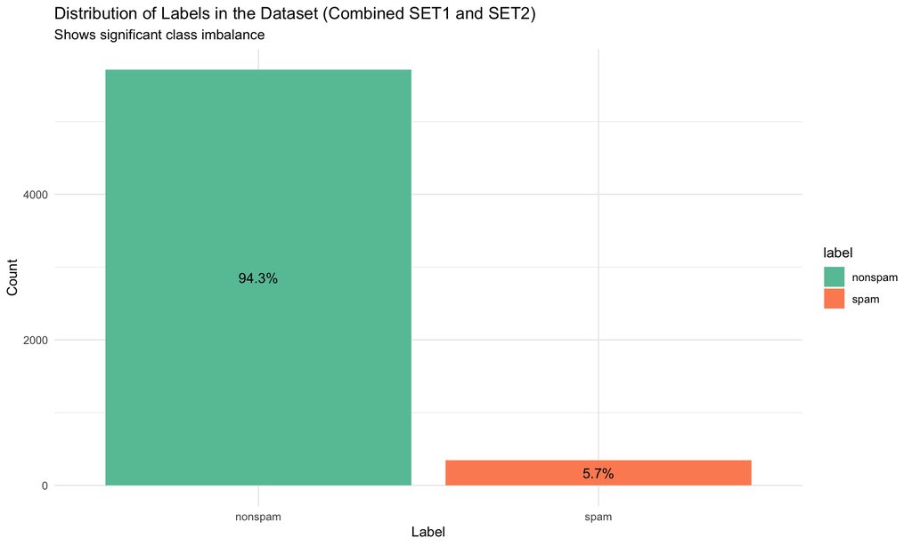

```r
# Analyze label distribution
label_dist <- all_labels %>%
  group_by(label) %>%
  summarise(count = n()) %>%
  mutate(percentage = count / sum(count) * 100)

# Create a bar plot of label distribution
ggplot(label_dist, aes(x = label, y = count, fill = label)) +
  geom_bar(stat = "identity") +
  geom_text(aes(label = sprintf("%.1f%%", percentage)),
            position = position_stack(vjust = 0.5)) +
  theme_minimal() +
  labs(title = "Distribution of Labels in the Dataset (Combined SET1 and SET2)",
       x = "Label",
       y = "Count",
       subtitle = "Shows significant class imbalance") +
  scale_fill_brewer(palette = "Set2")
```

```r
# Print detailed distribution
cat("\nDetailed Label Distribution:\n")
```

```
##
## Detailed Label Distribution:
```

```r
cat("SET1 (Training):",
    "\n- Non-spam:", sum(labels_set1$label == "nonspam"),
    "\n- Spam:", sum(labels_set1$label == "spam"),
    "\n\nSET2 (Testing):",
    "\n- Non-spam:", sum(labels_set2$label == "nonspam"),
    "\n- Spam:", sum(labels_set2$label == "spam"),
    "\n\nCombined:",
    "\n- Non-spam:", sum(all_labels$label == "nonspam"),
    "\n- Spam:", sum(all_labels$label == "spam"),
    "\n\nAnalysis: The dataset shows severe class imbalance, with spam samples being significantly underrepresented.")
```

```
## SET1 (Training):
## - Non-spam: 3776
## - Spam: 222
##
## SET2 (Testing):
## - Non-spam: 1933
## - Spam: 122
##
## Combined:
## - Non-spam: 5709
## - Spam: 344
##
## Analysis: The dataset shows severe class imbalance, with spam samples being significantly underrepresented.
```

## Feature Analysis and Standardization Requirements

> This chunk creates comprehensive summaries of each feature set, including the number of features, sample sizes, missing values, and value ranges to determine standardization requirements.

```r
# Function to create feature summary
create_feature_summary <- function(data, feature_set_name) {
  # Remove ID and label columns
  feature_cols <- data %>%
    select(-hostid, -is_spam) %>%
    # Remove hostname if it exists
    select(-any_of("hostname")) %>%
    names()

  # Calculate summary statistics
  summary_stats <- data %>%
    select(all_of(feature_cols)) %>%
    summary()

  # Check for missing values
  missing_count <- sum(is.na(data[feature_cols]))

  # Calculate value ranges
  value_ranges <- data %>%
    select(all_of(feature_cols)) %>%
    summarise(across(everything(), list(min = min, max = max))) %>%
    gather() %>%
    summarise(
      min_value = min(value),
      max_value = max(value)
    )

  # Combine into a data frame
  tibble(
    feature_set = feature_set_name,
    n_features = length(feature_cols),
    n_samples = nrow(data),
    missing_values = missing_count,
    value_range = sprintf("%.2f to %.2f", value_ranges$min_value, value_ranges$max_value),
    needs_standardization = if(value_ranges$max_value - value_ranges$min_value > 10) "Yes" else "No"
  )
}

# Create summaries for each feature set
feature_summaries <- bind_rows(
  create_feature_summary(direct_with_labels, "Direct Features"),
  create_feature_summary(link_with_labels, "Link-based Features"),
  create_feature_summary(content_with_labels, "Content-based Features")
)

# Display the summary table
feature_summaries %>%
  kable(caption = "Summary of Feature Sets") %>%
  kable_styling(bootstrap_options = c("striped", "hover"))
```

Summary of Feature Sets

| feature_set | n_features | n_samples | missing_values | value_range | needs_standardization |
| --- | --- | --- | --- | --- | --- |
| Direct Features | 2 | 6053 | 0 | 1.00 to 49999.00 | Yes |
| Link-based Features | 138 | 6053 | 0 | -67.15 to 838316.53 | Yes |
| Content-based Features | 96 | 5797 | 0 | -0.00 to 6999579326.73 | Yes |

```r
cat("\nFeature Set Analysis:\n")
```

```
##
## Feature Set Analysis:
```

```r
cat("1. Direct Features (obvious features):\n",
    "- Contains count-based features with varying scales\n",
    "- Standardization needed due to different scales\n\n")
```

```
## 1. Direct Features (obvious features):
##  - Contains count-based features with varying scales
##  - Standardization needed due to different scales
```

```r
cat("2. Link-based Features (transformed):\n",
    "- Already includes some transformations (e.g., logarithmic)\n",
    "- Still shows wide value ranges\n",
    "- Standardization recommended for consistent scaling\n\n")
```

```
## 2. Link-based Features (transformed):
##  - Already includes some transformations (e.g., logarithmic)
##  - Still shows wide value ranges
##  - Standardization recommended for consistent scaling
```

```r
cat("3. Content-based Features:\n",
    "- Mix of different metrics and scales\n",
    "- Standardization needed for comparable feature importance\n")
```

```
## 3. Content-based Features:
##  - Mix of different metrics and scales
##  - Standardization needed for comparable feature importance
```

> This chunk implements the data cleaning and standardization process for each feature set, handling missing values and normalizing features to ensure comparable scales.

> > All features were standardized using Z-score normalization (mean = 0, standard deviation = 1) via R’s scale() function. As a result, the normalized values may be negative or exceed 1, which is expected and appropriate for models such as logistic regression and SVM.

```r
# Function to clean and normalize features
clean_and_normalize <- function(data) {
  # Remove ID and target columns for processing
  features <- data %>%
    select(-hostid, -is_spam) %>%
    # Remove hostname if it exists
    select(-any_of("hostname"))

  # Handle missing values
  features <- features %>%
    mutate_all(~ifelse(is.na(.), mean(., na.rm = TRUE), .))

  # Normalize features
  features_normalized <- scale(features)

  # Combine normalized features with ID and target
  result <- cbind(
    data %>% select(hostid, is_spam),
    as.data.frame(features_normalized)
  )

  # Add hostname back if it exists in original data
  if ("hostname" %in% names(data)) {
    result <- cbind(
      result %>% select(hostid),
      data %>% select(hostname),
      result %>% select(-hostid)
    )
  }

  result
}

# Clean and normalize each feature set
direct_clean <- clean_and_normalize(direct_with_labels)
link_clean <- clean_and_normalize(link_with_labels)
content_clean <- clean_and_normalize(content_with_labels)
```

# 3. Classification Methods Selection and Implementation

### 1. Set 1: Direct Features (2 features)

> This chunk implements logistic regression for the direct features set, including model training, prediction, and performance evaluation. Both single split ROC and CV AUC are computed.

```r
library(caret)
library(pROC)

set.seed(42)
direct_idx <- createDataPartition(direct_clean$is_spam, p = 0.7, list = FALSE)
direct_train <- direct_clean[direct_idx, ] %>% select(is_spam, number_of_pages, length_of_hostname)
direct_test <- direct_clean[-direct_idx, ] %>% select(is_spam, number_of_pages, length_of_hostname)

direct_model <- glm(is_spam ~ ., data = direct_train, family = "binomial")
direct_pred_prob <- predict(direct_model, direct_test, type = "response")
direct_pred_label <- ifelse(direct_pred_prob >= 0.5, 1, 0)
direct_cm <- caret::confusionMatrix(factor(direct_pred_label), factor(direct_test$is_spam), positive = "1")
direct_precision <- direct_cm$byClass["Precision"]
direct_recall <- direct_cm$byClass["Recall"]
direct_f1 <- direct_cm$byClass["F1"]

# direct_roc is used in step 4 for comparsion
direct_roc <- roc(direct_test$is_spam, direct_pred_prob)

# CV AUC (only numeric features)
# 5 折交叉验证（Cross-Validation）计算平均 AUC
cv_folds <- createFolds(direct_clean$is_spam, k = 5, list = TRUE, returnTrain = FALSE)
direct_auc_cv <- mean(sapply(cv_folds, function(idx) {
  train <- direct_clean[-idx, ] %>% select(is_spam, number_of_pages, length_of_hostname)
  test <- direct_clean[idx, ] %>% select(is_spam, number_of_pages, length_of_hostname)
  model <- glm(is_spam ~ ., data = train, family = "binomial")
  pred <- predict(model, test, type = "response")
  auc(roc(test$is_spam, pred, quiet=TRUE))
}))
cat("\nDirect Features 5-fold CV Mean AUC:", round(direct_auc_cv, 4), "\n")
```

```
##
## Direct Features 5-fold CV Mean AUC: 0.5245
```

```r
# 检查预测标签分布
cat("Direct pred label table:\n")
```

```
## Direct pred label table:
```

```r
print(table(direct_pred_label))
```

```
## direct_pred_label
##    0
## 1815
```

```r
cat("Direct test true label table:\n")
```

```
## Direct test true label table:
```

```r
print(table(direct_test$is_spam))
```

```
##
##    0    1
## 1708  107
```

### 2. Set 2: Link-based Features (138 features)

- **Selected Method**: Random Forest
- **Justification**:
  - High-dimensional feature space (138 features)
  - Excellent performance with high-dimensional data
  - Built-in feature importance evaluation
  - Robust to different scales and non-linear relationships
  - Handles class imbalance well with proper weighting
- **Additional Considerations**:
  - Will use class weights to address imbalance
  - No need for additional feature scaling

> This chunk implements random forest classification for the link-based features, including single split ROC and CV AUC.

```r
library(randomForest)
library(pROC)
library(caret)

# Link features: single split for ROC, CV for AUC
set.seed(42)
link_train_index <- createDataPartition(link_clean$is_spam, p = 0.7, list = FALSE)
link_train <- link_clean[link_train_index, ]
link_test <- link_clean[-link_train_index, ]

# Single split model for ROC
# 处理不平衡
class_weights <- ifelse(link_train$is_spam == 1,
                       (1/table(link_train$is_spam)[2]) * 0.5,
                       (1/table(link_train$is_spam)[1]) * 0.5)
#单次训练模型用于ROC画图（500棵树）
link_model <- randomForest(factor(is_spam) ~ ., data = link_train, weights = class_weights, ntree = 500, importance = TRUE)
link_pred_prob <- predict(link_model, link_test, type = "prob")[,2]
link_roc <- roc(link_test$is_spam, link_pred_prob)

# 5-fold cross validation for AUC（200棵树）
cv_folds <- createFolds(link_clean$is_spam, k = 5, list = TRUE, returnTrain = FALSE)
link_auc_cv <- mean(sapply(cv_folds, function(idx) {
  train <- link_clean[-idx, ]
  test <- link_clean[idx, ]
  cw <- ifelse(train$is_spam == 1, (1/table(train$is_spam)[2]) * 0.5, (1/table(train$is_spam)[1]) * 0.5)
  model <- randomForest(factor(is_spam) ~ ., data = train, weights = cw, ntree = 200)
  pred <- predict(model, test, type = "prob")[,2]
  auc(roc(test$is_spam, pred, quiet=TRUE))
}))
cat("\nLink Features 5-fold CV Mean AUC:", round(link_auc_cv, 4), "\n")
```

```
##
## Link Features 5-fold CV Mean AUC: 0.7345
```

```r
# Link Features 混淆矩阵和指标
link_pred_label <- ifelse(link_pred_prob >= 0.5, 1, 0)
link_cm <- caret::confusionMatrix(factor(link_pred_label), factor(link_test$is_spam), positive = "1")
link_precision <- link_cm$byClass["Precision"]
link_recall <- link_cm$byClass["Recall"]
link_f1 <- link_cm$byClass["F1"]
```

### 3. Set 3: Content-based Features (96 features)

> This chunk implements SVM classification for the content-based features, including single split ROC and CV AUC.

```r
library(e1071)
library(pROC)
library(caret)

# Content features: single split for ROC, CV for AUC
set.seed(42)
content_train_index <- createDataPartition(content_clean$is_spam, p = 0.7, list = FALSE)
content_train <- content_clean[content_train_index, ]
content_test <- content_clean[-content_train_index, ]

# Exclude only hostid and hostname, keep all other features (including is_spam)
content_train_num <- content_train %>% select(-hostid, -hostname)
content_test_num <- content_test %>% select(-hostid, -hostname)


# SVM建模，使用 radial basis function（径向基核）和类不平衡处理
model <- svm(is_spam ~ ., data = content_train_num, kernel = "radial", cost = 1, gamma = 0.1,
             class.weights = c("0" = 1, "1" = sum(content_train_num$is_spam == 0)/sum(content_train_num$is_spam == 1)),
             probability = FALSE)

decision <- attributes(predict(model, content_test_num, decision.values = TRUE))$decision.values

# 修正ROC方向：如果AUC小于0.5则自动翻转decision值
content_roc <- roc(content_test_num$is_spam, as.numeric(decision), levels = c(0, 1), direction = "<", positive = 1)
if (auc(content_roc) < 0.5) {
  content_roc <- roc(content_test_num$is_spam, -as.numeric(decision), levels = c(0, 1), direction = "<", positive = 1)
}

# CV AUC (exclude only hostid, hostname)
# 分fold
cv_folds <- createFolds(content_clean$is_spam, k = 5, list = TRUE, returnTrain = FALSE)

content_auc_cv <- mean(sapply(cv_folds, function(idx) {
  #去掉hostid, hostname field
  train <- content_clean[-idx, ] %>% select(-hostid, -hostname)
  test <- content_clean[idx, ] %>% select(-hostid, -hostname)
  # svm模型训练，精细调整需要调整cost=1, gamma=0.1两个参数
  m <- svm(is_spam ~ ., data = train, kernel = "radial", cost = 1, gamma = 0.1,
           class.weights = c("0" = 1, "1" = sum(train$is_spam == 0)/sum(train$is_spam == 1)), probability = FALSE)
  dec <- attributes(predict(m, test, decision.values = TRUE))$decision.values
  auc(roc(test$is_spam, as.numeric(dec), quiet=TRUE))
}))

cat("\nContent Features 5-fold CV Mean AUC:", round(content_auc_cv, 4), "\n")
```

```
##
## Content Features 5-fold CV Mean AUC: 0.7878
```

```r
# Content Features 混淆矩阵和指标
content_pred_label <- ifelse(as.numeric(decision) >= 0, 1, 0)
content_cm <- caret::confusionMatrix(factor(content_pred_label), factor(content_test_num$is_spam), positive = "1")
content_precision <- content_cm$byClass["Precision"]
content_recall <- content_cm$byClass["Recall"]
content_f1 <- content_cm$byClass["F1"]
```